# HW 1

SDS 322E

September 02, 2022

#### lb36634

**Please submit as an HTML file on Canvas before the due date**

*For all questions, include the R commands/functions that you used to find your answer. Answers without supporting code will not receive credit.*

##### How to submit this assignment

> All homework assignments will be completed using R Markdown. These `.Rmd` files consist of text/syntax (formatted using Markdown) alongside embedded R code. When you have completed the assignment (by adding R code inside codeblocks and supporting text outside codeblocks), create your document as follows:
> - Click the “Knit” button (above)
> - Fix any errors in your code, if applicable
> - Upload the HTML file to Canvas

## Q1 (1 pts)

##### The dataset `quakes` contains information about earthquakes occurring near Fiji since 1964. The first few observations are listed below.

```r
head(quakes)
```

```
##      lat   long depth mag stations
## 1 -20.42 181.62   562 4.8       41
## 2 -20.62 181.03   650 4.2       15
## 3 -26.00 184.10    42 5.4       43
## 4 -17.97 181.66   626 4.1       19
## 5 -20.42 181.96   649 4.0       11
## 6 -19.68 184.31   195 4.0       12
```

##### How many observations are there of each variable (i.e., how many rows are there; show using code)? How many variables are there total (i.e., how many columns are in the dataset)? You can read more about the dataset [here](https://stat.ethz.ch/R-manual/R-patched/library/datasets/html/quakes.html) *Do not forget to include the code you used to find the answer each question*

```r
# your code here
NROW(quakes)
```

```
## [1] 1000
```

```r
NCOL(quakes)
```

```
## [1] 5
```

*Your typed answer goes here. 1-2 sentences only.*

## There are 1000 obervations and 5 Variables Total [lat, long, depth, mag, stations].

## Q2 (2 pts)

##### What are the minimum, maximum, mean, and median values for the variables `mag` and `depth`? Note that there are many functions that can be used to answer this question. If you chose to work with each variable separately, recall that you can access individual variables in a dataframe using the `$` operator (e.g., `dataset$variable`). Describe your answer in words.

```r
# your code here

min(head(quakes)$mag)
```

```
## [1] 4
```

```r
max(head(quakes)$mag)
```

```
## [1] 5.4
```

```r
mean(head(quakes)$mag)
```

```
## [1] 4.416667
```

```r
median(head(quakes)$mag)
```

```
## [1] 4.15
```

```r
min(head(quakes)$depth)
```

```
## [1] 42
```

```r
max(head(quakes)$depth)
```

```
## [1] 650
```

```r
mean(head(quakes)$depth)
```

```
## [1] 454
```

```r
median(head(quakes)$depth)
```

```
## [1] 594
```

## Q3

##### Recall how logical indexing of a dataframe works in R. To refresh your memory, in the example code below I ask R for the median magnitude for quakes whose longitude is greater than 175. The two ways produce equivalent results.

```r
median(quakes$mag[quakes$long > 175])
```

```
## [1] 4.5
```

```r
median(quakes[quakes$long > 175, ]$mag)  #this is the more conventional notation
```

```
## [1] 4.5
```

### 3.1 (1 pt)

##### Explain what each of the two lines of code are doing in words. Specifically, why do we need to use the comma in the second case but not in the first? Remember that the `$` selects a single variable that `[ ]` are used for indexing whatever object came before (either a single variable or a dataframe).

*Your answer goes here. 1-2 sentences only.*

## Since $ Accesses individual Variables the first one looks into the magnitudes first and checks for while the second checks the entire list for items more than 175 and then references mag.The comma is necessary for the second case bc it ignores the second parameter of whatever it is trying to gain.

### 3.2 (3 pts)

##### What is the mean of the variable `mag` when `depth` is *greater than* the median depth? What is the mean of the variable `mag` when `depth` is *less than* the median depth? What does this suggest about the relationship between an earthquake’s depth and its magnitude?

```r
# your code here

mean(quakes$mag[quakes$depth > median(quakes$depth)])
```

```
## [1] 4.5232
```

```r
mean(quakes$mag[quakes$depth < median(quakes$depth)])
```

```
## [1] 4.7176
```

*Your answer goes here. 1-2 sentences only.*

## The depth and Magnitude are inversly related.

### 3.3 (2 pts)

##### What is the standard deviation of the variable `lat` when `depth` is *greater than* the median depth? What is the standard deviation of the variable `lat` when `depth` is *less than* the median depth? What does this suggest about the relationship between an earthquake’s latitude and it’s depth?

```r
# your code here

sd(quakes$lat[quakes$depth > median(quakes$depth)])
```

```
## [1] 3.577252
```

```r
sd(quakes$lat[quakes$depth < median(quakes$depth)])
```

```
## [1] 6.1501
```

## Q4 (2 pts)

##### The variable `depth` is measured in kilometers. Create a new variable called `depth_m` that gives depth **in meters rather than kilometers** and add it to the dataset `quakes`. To help get you started, I have given you code that creates the new variable but fills it with `NA` values. Overwrite the `NA`s below by writing code on the right-hand side of the assignment operator (`<-`) that computes the requested transformation. Print out the first few rows of the updated dataset using `head()`.

```r
# update the code below by replacing the NA with
# the correct expression to convert to meters

quakes$depth_m <- quakes$depth * 1000
head(quakes$depth_m, n = 10)
```

```
##  [1] 562000 650000  42000 626000 649000 195000  82000 194000 211000 622000
```

## Q5

##### Let’s make some plots in base R.

### 5.1 (2 pt)

##### Create a boxplot of `depth` using the `boxplot()` function. Describe where you see the min, max, and median (which you calculated in question 2) in this plot.

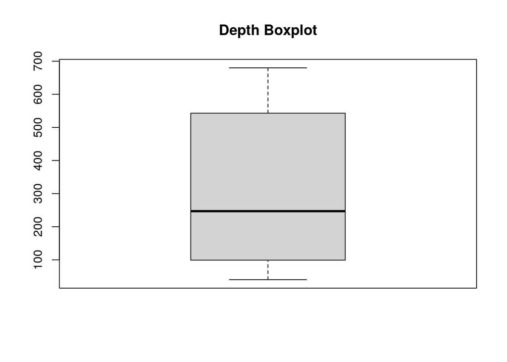

```r
# your code here

boxplot(quakes$depth, main = "Depth Boxplot")
```

### 5.2 (2 pt)

##### Create a histogram of `depth` using the `hist()` function. What important information does the histogram provide that the boxplot does not?

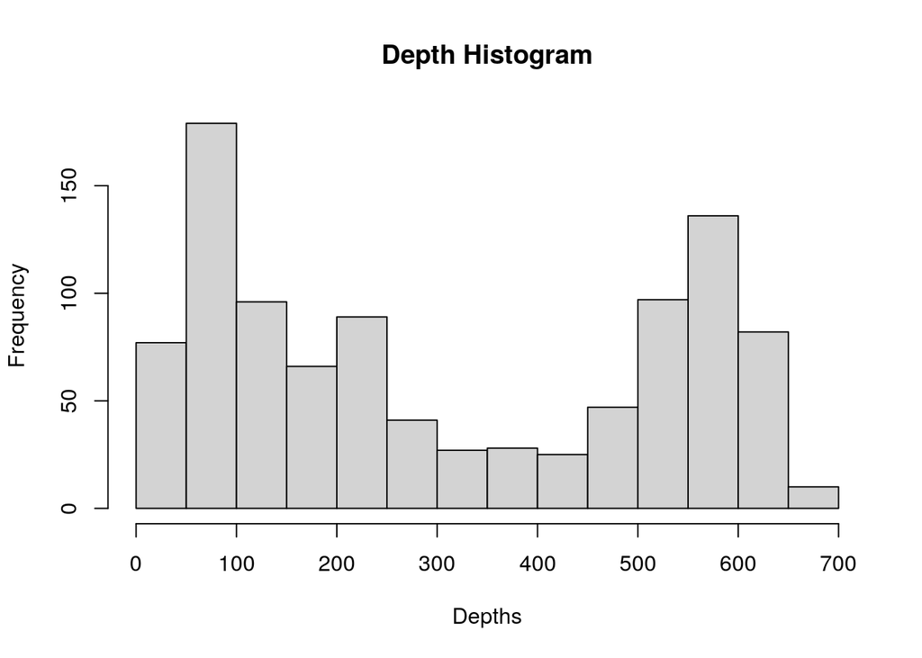

```r
# your code here

hist(quakes$depth, main = "Depth Histogram", xlab = "Depths")
```

*Your answer goes here. 1-2 sentences only.*

## A histogram describes the data set at ease of understanding. We can see how a graph is skewed and how its distributed, espically how its split in the middle.

### 5.3 (2 pt)

##### Create a scatterplot by plotting variables `mag` and `stations` against each other using the `plot()` function. Note that to generate a scatterplot, the `plot()` takes two arguments: the x-axis variable and the y-axis variable. Describe the relationship between the two variables.

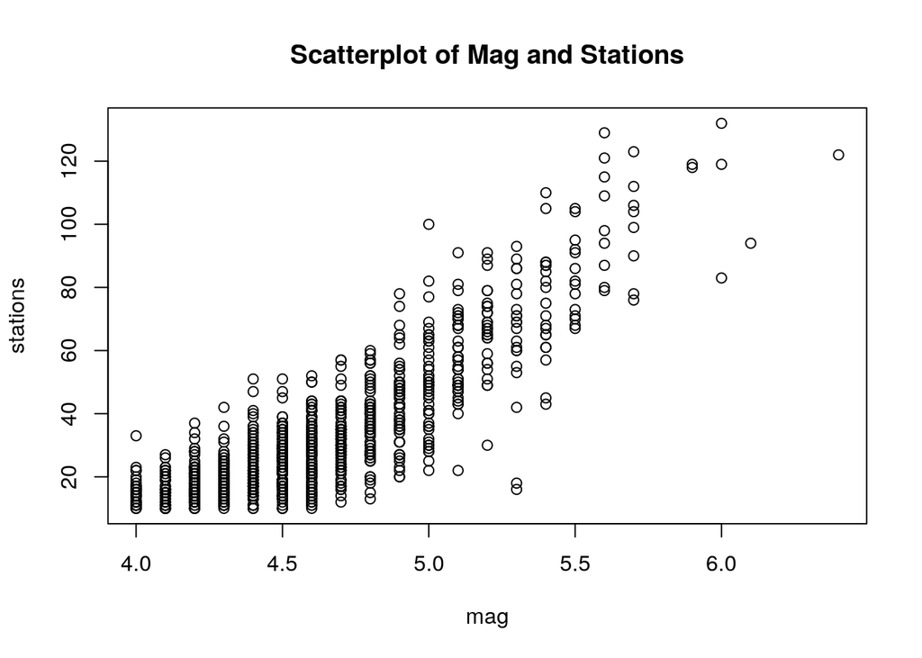

```r
# your code here

plot(quakes$mag, quakes$stations, main = "Scatterplot of Mag and Stations",
    xlab = "mag", ylab = "stations")
```

*Your answer goes here. 1-2 sentences only.*

## Mag. and Stations have a positive linear relationship that with some points are outliers, more as we go outward.

### 5.4 (3 pt)

##### Create scatterplot of the quakes’ geographic locations by plotting `long` on the x-axis and `lat` on the y-axis. Using this plot, and the map/link below (note the two trenches), and some of the techniques you practiced above, are deeper quakes more likely to originate east or west of Fiji?

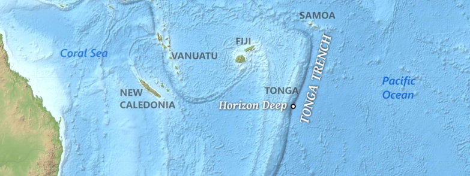

[Link to location on Google maps](https://www.google.com/maps/@-20.1679389,175.7587479,3513560m/data=!3m1!1e3)

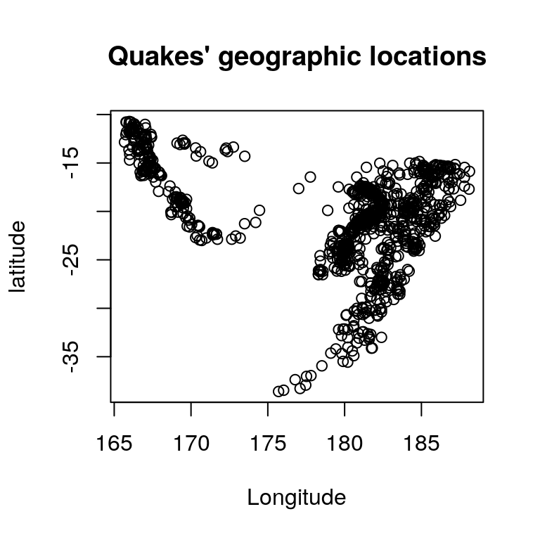

```r
# your code here

plot(x = quakes$long, y = quakes$lat, main = "Quakes' geographic locations",
    xlab = "Longitude", ylab = "latitude")
```

```r
mean(quakes$depth[quakes$long > 175])
```

```
## [1] 347.9182
```

```r
mean(quakes$depth[quakes$long < 175])
```

```
## [1] 169.639
```

```
## [1] "2022-09-02 19:36:21 CDT"
```

[output not shown]